# Final Project

## Modelling

#### Function to calculate model performance

```python
def evaluate_model(y_true, y_pred, model_name):
    results = {
        'Model': model_name,
        'Accuracy': round(accuracy_score(y_true, y_pred), 4),
        'F1 Score': round(f1_score(y_true, y_pred, average='weighted'), 4),
        'MSE': round(mean_squared_error(y_true, y_pred), 4),
        'MAE': round(mean_absolute_error(y_true, y_pred), 4),
        'Precision': round(precision_score(y_true, y_pred, average='weighted'), 4),
        'Recall': round(recall_score(y_true, y_pred, average='weighted'), 4)
    }
    return results
```

#### Random Forest Model

```python
# Initialize and Train Random Forest Model
rf_model = RandomForestClassifier(random_state=22)
rf_model.fit(X_train, Y_train)

# Save the model
joblib.dump(rf_model, os.path.join(model_dir, 'random_forest_model.joblib'))

# Predict on validation data
rf_predictions = rf_model.predict(X_validation)

# Evaluate model
rf_results = evaluate_model(Y_validation, rf_predictions, 'Random Forest')
rf_results
```

```
{'Model': 'Random Forest',
 'Accuracy': 0.3253,
 'F1 Score': 0.3249,
 'MSE': 1.4147,
 'MAE': 0.9213,
 'Precision': 0.325,
 'Recall': 0.3253}
```

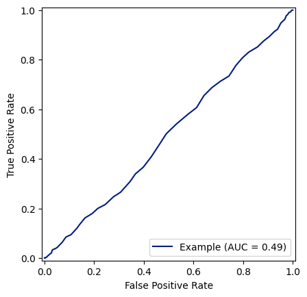

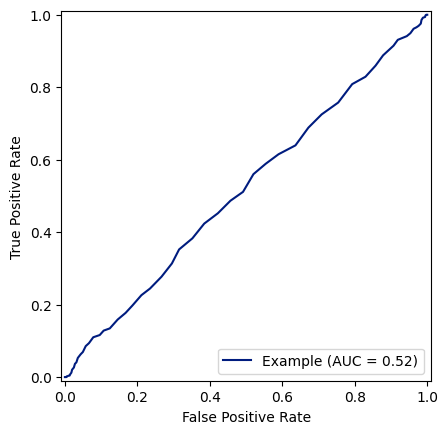

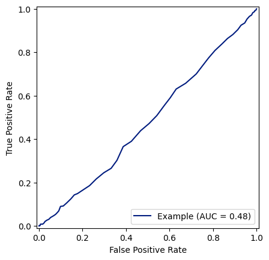

```python
#Roc Curve
# Binarize the output
y_bin = label_binarize(Y_validation, classes=[0, 1, 2])
n_classes = y_bin.shape[1]

# Learn to predict each class against the other
classifier = OneVsRestClassifier(RandomForestClassifier(random_state=22))
Y_score = classifier.fit(X_train, label_binarize(Y_train, classes=[0, 1, 2])).predict_proba(X_validation)

# Compute ROC curve and ROC area for each class
fpr = dict()
tpr = dict()
roc_auc = dict()
for i in range(n_classes):
    fpr[i], tpr[i], _ = roc_curve(y_bin[:, i], Y_score[:, i])
    roc_auc[i] = auc(fpr[i], tpr[i])

# Plot ROC curve for each class
for i in range(n_classes):
    plt.figure()
    RocCurveDisplay(fpr=fpr[i], tpr=tpr[i], roc_auc=roc_auc[i],
                    estimator_name='Example').plot()
```

- The ROC curves have AUC values of 0.49, 0.52, and 0.48. These values are very close to 0.5, which suggests that the classifier performance is near that of random guessing and indicates that the model has no discriminative ability to distinguish between positive and negative classes. [For more information:](https://scikit-learn.org/stable/modules/generated/sklearn.metrics.roc_curve.html)

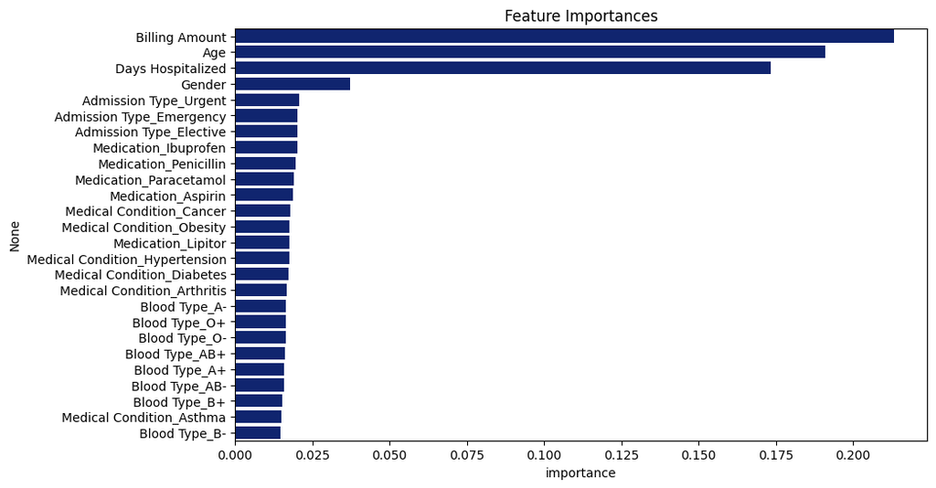

```python
#feature importances:
feature_importances = pd.DataFrame(rf_model.feature_importances_,
                                   index = X_train.columns,
                                   columns=['importance']).sort_values('importance', ascending=False)

plt.figure(figsize=(10,6))
sns.barplot(x="importance", y=feature_importances.index, data=feature_importances)
plt.title('Feature Importances')
plt.show()
```

- The above graph gives a feature importance based on the score. [For more information:](https://scikit-learn.org/stable/auto_examples/ensemble/plot_forest_importances.html)

#### Gradient Boosting Classifier

```python
# Initialize and Train Gradient Boosting Model
gb_model = GradientBoostingClassifier(random_state=22)
gb_model.fit(X_train, Y_train)

# Save the model
joblib.dump(gb_model, os.path.join(model_dir, 'gradient_boosting_model.joblib'))

# Predict on validation data
gb_predictions = gb_model.predict(X_validation)

# Evaluate model
gb_results = evaluate_model(Y_validation, gb_predictions, 'Gradient Boosting')
gb_results
```

```
{'Model': 'Gradient Boosting',
 'Accuracy': 0.3533,
 'F1 Score': 0.3475,
 'MSE': 1.3567,
 'MAE': 0.8833,
 'Precision': 0.3504,
 'Recall': 0.3533}
```

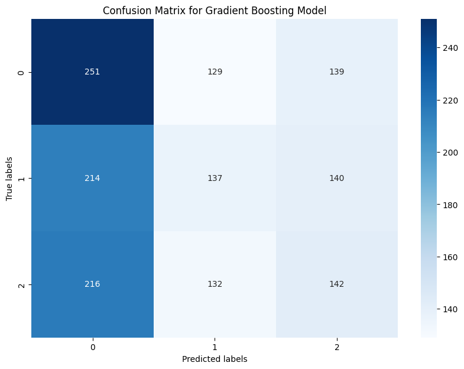

```python
# Generate the confusion matrix
cm = confusion_matrix(Y_validation, gb_predictions)
plt.figure(figsize=(10,7))
sns.heatmap(cm, annot=True, fmt='g', cmap='Blues')
plt.xlabel('Predicted labels')
plt.ylabel('True labels')
plt.title('Confusion Matrix for Gradient Boosting Model')
plt.show()
```

##### Class 0:

- True Positives (TP): The model correctly predicted 251 instances as class 0.
- False Negatives (FN): The model incorrectly predicted 129 instances as class 1 and 139 instances as class 2, which were actually class 0. These are the instances where the model failed to recognize class 0.

##### Class 1:

- True Positives (TP): The model correctly predicted 137 instances as class 1.
- False Negatives (FN): The model incorrectly predicted 214 instances as class 0 and 140 instances as class 2, which were actually class 1.

##### Class 2:

- True Positives (TP): The model correctly predicted 142 instances as class 2.
- False Negatives (FN): The model incorrectly predicted 216 instances as class 0 and 132 instances as class 1, which were actually class 2.